# Modeling the Covid-19 pandemic

Dani Gamerman

### Modelling the Covid19 pandemic

Dani Gamerman - Graduate Program in Statistics - UFMG

*1st semester 2020*

(inspired on notes by José Marcos Andrade Figueiredo - UFMG)

#### Basic logistic growth model

$$Y(t) \sim N ( \mu (t) , \sigma^2 ), \qquad t = 1, 2, ...$$

where $Y(t)$ is the **cumulated number of confirmed cases** by day $t$ in a given region, with $\mu ( t ) = \frac{ a \exp{ \{ c t \} } } {1 + b \exp { \{ c t \} }}.$

**Special case:**

- $b = 0$ (exponential growth) $\rightarrow \mu(t) = a \exp \{ ct \}$;
- adequate for early stages of the pandemic.

##### **Problems of the basic model:**

1. data are **counts**, and the normal distribution assumes continuous data;
2. variance should increase with data magnitude.

#### Characteristics of interest

The most important characteristics are:

**1) Infection rate**

- $c$ measures the acceleration of growth and reflects the infection rate of the disease.

**2) Assintote**

$\lim_{t \to \infty} \mu( t) = \lim_{t \to \infty} \frac{ a \exp{ \{ c t \} } } {1 + b \exp { \{ ct \} }} = \frac ab$

- Reflects the total number of cases accumulated throughout the whole trajectory of the pandemic.
- Exponential growth ($b=0$): assintote $= \infty$ !

**3) Peak of the pandemic**

- Defined as the time $t^*$ where number of new cases stops growing and starts to decrease.
- Exponential growth ($b=0$): number of new cases never stops growing!

**4) Prediction**

- What can be said about $Y (t+k ), \forall k$, for $t$ fixed (today)?

  It depends on the distribution of $Y(t)$ but will always be given by the predictive distribution of $Y(t+k)$ given $Y(1:t) = \{ Y(1) , ... , Y(t) \}$ - what was observed.

  It works as the posterior distribution of $Y(t + k )$.

**Useful result:** If $Z$ and $W$ are any 2 r. v.’s then:

- $E[Z] = E[ E(Z \mid W ) ]$
- $Var[Z] = Var[ E(Z \mid W ) ] + E[ Var( Z \mid W ) ]$

In particular, $E[Y ( t + k ) \mid Y( 1:t)] = E\{ E[ Y ( t + k ) \mid \mu( 1:t)] \mid Y( 1:t) \} = E[ \mu( t+k )] \mid Y( 1:t) ]$, the posterior mean of $\mu ( t + k )$.

Inference about all that was described above should be reported through point estimators (eg: posterior means), along with respective credibility intervals.

**5) Reproducibility rate $R_0$**

$R_0$ is the expected number of secondary cases of a disease caused by an infected individual.

At time $t$, it is defined as $R_0 = \frac {\mu ( t ) - \mu ( t-1)}{\mu ( t-1)} = \frac {\mu ( t )}{\mu ( t-1)} - 1$.

- **Beginning of the pandemic:** $1 \gg b \exp { \{ ct \} } \to \mu (t) \approx a \exp { \{ ct \} } \to R_0 \approx e^c - 1$
- **End of the pandemic:** $1 \ll b \exp { \{ ct \} } \to \mu (t) \approx a / b \to R_0 \approx 0$
- **Middle of the pandemic:** $R_0$ is a function of parameters $(a,b,c)$ and time $t$, and is given by $R_0 (t) = e^c \ \frac{1 + b e^c e^{ct} } {1 + b e^{ct} } \ - \ 1$.

For any fixed $t$, one can obtain its posterior distribution (via MCMC sample) and calculate mean, quantiles and credibility intervals.

**6) Mean number of new cases (MNNC)**

Mean number of new cases at time $t+k$:

$n_t ( k ) = E [Y ( t + k ) - Y ( t + k -1 ) ] = \mu ( t + k ) - \mu ( t + k -1 )$

Thus, MNNC is also a function of parameters $(a,b,c)$ and can be easily calculated.

For any fixed $t$ and $k$, one can obtain its posterior distribution (via MCMC sample) and calculate mean, quantiles and credibility intervals.

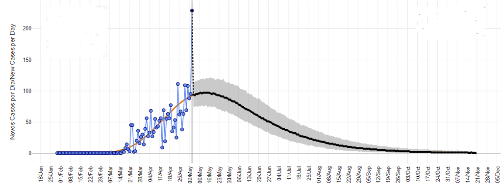

#### Alternatives:

1.1) $Y( t ) \sim Poisson ( \mu ( t ) )$ with $E[ Y(t)] = \mu (t )$ and $Var(Y(t)) = \mu ( t )$

1.2) $Y ( t ) \sim N ( \mu ( t ) , \sigma^2 \ \mu ( t ) )$ with $E[ Y(t)] = \mu (t )$ and $Var(Y(t)) = \sigma^2 \ \mu ( t )$

Observações:

- Model (1.2) admits overdispersion if $\sigma^2 > 1$
- Alternative (1.2) only handles comment (b)
- Alternative (1.1) handles the two comments but does not allow overdispersion

##### **Poisson with overdispersion**

1.3) $Y( t ) \mid \epsilon ( t ) \sim Poisson ( \mu ( t ) + \epsilon ( t ) )$ with $E[ \epsilon (t)] = 0$ and $Var( \epsilon (t)) = \sigma^2$

1.4) $Y( t ) \mid \epsilon ( t ) \sim Poisson ( \mu ( t ) \times \epsilon ( t ) )$ with $E[ \epsilon (t)] = 1$ and $Var( \epsilon (t)) = \sigma^2$

Considering the usefull results presented above:

Mod(1.3):

- $E [ Y ( t ) ] = E[ E( Y(t) \mid \epsilon (t ) ) ] = E[ \mu ( t ) + \epsilon ( t ) ] = \mu ( t ) + E[ \epsilon ( t ) ] = \mu ( t )$
- $Var[ Y ( t ) ] = Var[ E( Y(t) \mid \epsilon (t) ) ] + E[ Var ( Y(t) \mid \epsilon (t) ) ] = Var[ \mu ( t ) + \epsilon ( t ) ] + E [ \mu ( t ) + \epsilon ( t ) ] = \sigma^2 + \mu_t > \mu ( t )$

Mod(1.4):

- $E [ Y ( t ) ] = E[ E( Y(t) \mid \epsilon (t) ) ] = E[ \mu ( t ) \times \epsilon ( t ) ] = \mu ( t ) \times E[ \epsilon ( t ) ] = \mu ( t )$
- $Var[ Y ( t ) ] = Var[ E( Y(t) \mid \epsilon (t) ) ] + E[ Var ( Y(t) \mid \epsilon (t) ) ] = Var[ \mu ( t ) \times \epsilon ( t ) ] + E [ \mu ( t ) \times \epsilon ( t ) ] = \mu_t ^2 \sigma^2 + \mu_t > \mu ( t )$

Both preserve Poisson mean but increase Poisson dispersion.

#### Dynamic extensions

Previous models assume static behaviour:

- shape of the disease does not modify along time;
- infection rate will always be the same, assintote will always be the same, …

**Dynamic models** make it flexible.

##### 1. **Dynamic models**

$\mu ( t ) = \frac{ a( {\color{red} t )} \ \exp{ \{ c( {\color{red}t) } \ t \} } } {1 + b( {\color{red}t) } \ \exp { \{ c({\color{red}t) } \ t \} }}$

with: $a ( t ) = a ( t-1) + w_a ( t )$, where $w_a ( t ) \sim N ( 0 , W_a ), \forall t$.

$b ( t ) = b ( t-1) + w_b ( t )$, where $w_b ( t ) \sim N ( 0 , W_b ), \forall t$.

$c ( t ) = c ( t-1) + w_c ( t )$, where $w_c ( t ) \sim N ( 0 , W_c ), \forall t$.

**Advantages:**

1. $E[ a(t) \mid a(t-1 )]= a (t-1)$, and the same goes for $b(t)$ and $c(t) \Rightarrow$ local constancy.
2. $Var[ a(t) \mid a(t-1 )]= W_a$, and the same goes for $b(t)$ and $c(t) \Rightarrow$ increase in uncertainty.

**Problems:**

1. variances $W_a, W_b, W_c$ unknown $\Rightarrow$ difficult to specify;
2. variances $W_a, W_b, W_c$ unknown $\Rightarrow$ difficult to estimate.
3. it os not possible to simplify $W_a = W_b = W_c = W$ (different magnitudes of $(a,b,c)$).

##### 2. **Multiplicative effect:**

Another form to introduce dynamics, now **multiplicative**:

$a ( t ) = a ( t-1) \times w_a ( t )$, where $w_a ( t ) \sim Gamma ( d_a ,d_a ), \forall t$.

$b ( t ) = b ( t-1) \times w_b ( t )$, where $w_b ( t ) \sim Gamma ( d_b ,d_b ), \forall t$.

$c ( t ) = c ( t-1) \times w_c ( t )$, where $w_c ( t ) \sim Gamma ( d_c ,d_c ), \forall t$.

**Advantages:**

1. $E[ a(t) \mid a(t-1 )]= a (t-1)$ and the same goes for $b(t)$ and $c(t) \Rightarrow$ local constancy.
2. $Var[ a(t) \mid a(t-1 )]= d_c^{-1}$ and the same goes for $b(t)$ and $c(t) \Rightarrow$ increase in uncertainty.
3. Hiperparameters $d_a, d_b, d_c$ easier to specify.

Examples: $d=1000 \ \to \ 0,90= P ( 0,95 < w(t) < 1,05 ) = P \left( 0,95 < \frac {a(t)}{a(t-1) } < 1,05 \right)$ $d=1500 \ \to \ 0,95= P ( 0,95 < w(t) < 1,05 ) = P \left( 0,95 < \frac {a(t)}{a(t-1) } < 1,05 \right)$

**Disadvantages:**

1. Magnitudes of $a, b, c$ still interfere in the increase in uncertainty.
2. Not sure if free software works fine with Gammas with such high parameter values.

##### 3. **Multiplicative evolution with normal errors**

Consider the multiplicative evolution below for parameter $a$:

$$a ( t ) = a ( t-1) \times \exp \{ w_a ( t ) \}, \mbox{ where } w_a ( t ) \sim N( 0 , W_a )$$
Taking logarithm on both sides, one obtains:
$$\log \ a ( t ) = \log \ a ( t-1) + w_a ( t ), \mbox{ where } w_a ( t ) \sim N( 0 , W_a )$$
Passing $\log \ a ( t-1)$ to the left, one obtains:
$$\log \ a ( t ) - \log \ a ( t-1) = \log \left[ \frac{ a ( t )}{ a ( t-1)} \right] = w_a ( t ), \mbox{ where } w_a ( t ) \sim N( 0 , W_a )$$

Specification of $W_a$: one can think of percentual increase, as before.

$$0,95 = P \left( 0,95 < \frac {a(t)}{a(t-1) } < 1,05 \right) = P ( - 0,05 < w_a(t) < 0,05 )$$
This implies $2 \sqrt{W_a} = 0,05$, that implies $\sqrt{W_a} = 0,025 \ \Rightarrow W_a = (0,025)^2$.

The same specification is valid for $W_b$ and $W_c$, since magnitudes of $b$ and $c$ do not matter.

- **Special case**

Based on Gamerman, Santos and Franco (J. Time Series Analysis, 2013):

$$\mu ( t ) = \frac{ a( {\color{red}t)} \ \exp{ \{ c \ t \} } } {1 + b \ \exp { \{ c \ t \} }}$$
$a ( t ) = a ( t-1) \times w_a ( t )$, where $w_a ( t ) \sim Beta, \forall t$.

It may also be used for exponencial growth($b=0$).

**Advantage:**

1. Allows exact calculation, thus avoiding (MCMC) approximations.

**Disadvantage:**

1. Does not allow dynamic $b$ and $c$.

#### Generalizations of the logistic curve

So far, logistic curve was used to specify the mean $\mu ( t )$ as $\mu ( t ) = \frac{ a \exp{ \{ c t \} } } {1 + b \exp { \{ ct \} }} = \frac{ a} { b + \exp { \{ - ct \} }}$.

This expression is the simplest logistic form. It can be generalized in many ways. One possible form of the **generalized logistic** is
$$\mu ( t ) = d + \frac{ a - d} {( b + \exp { \{ - ct \} } )^f}$$

The logistic curve is obtained by taking $d=0$ and $f=1$.